# Part II - (Explanatory-Presentation)

## Investigation Overview

> - Does gender affect the duration of the ride in the weekdays ?
> - What is the relation between user type and ride duration and days ?
> - How time, gender and user type are related ?

## Dataset Overview

> My chosen DataSet is showing information that covers over 170K records of individual rides made in a bike-sharing system covering the greater San Francisco Bay area in Feb-2019.

RangeIndex: 171230 entries, 0 to 171229 Data columns (total 23 columns):

- duration_sec - 171230 - non-null - int64
- start_station_id - 171230 - non-null - float64
- start_station_name - 171230 - non-null - object
- start_station_latitude - 171230 - non-null - float64
- start_station_longitude - 171230 - non-null - float64
- end_station_id - 171230 - non-null - float64
- end_station_name - 171230 - non-null - object
- end_station_latitude - 171230 - non-null - float64
- end_station_longitude - 171230 - non-null - float64
- bike_id - 171230 - non-null - int64
- user_type - 171230 - non-null - object
- member_gender - 171230 - non-null - object
- bike_share_for_all_trip - 171230 - non-null - object
- age - 171230 - non-null - float64
- start_day - 171230 - non-null - int64
- start_day_of_week - 171230 - non-null - object
- start_hour - 171230 - non-null - int64
- end_day - 171230 - non-null - int64
- end_day_of_week - 171230 - non-null - object
- end_hour - 171230 - non-null - int64
- month - 171230 - non-null - object
- start_day_part - 171230 - non-null - object
- end_day_part - 171230 - non-null - object

dtypes: float64(7), int64(6), object(10)

```python
# import all packages and set plots to be embedded inline
import numpy as np
import pandas as pd
import matplotlib.pyplot as plt
import seaborn as sns

%matplotlib inline

# suppress warnings from final output
import warnings
warnings.simplefilter("ignore")
```

```python
# load in the dataset into a pandas dataframe
# uploading data using colab
#from google.colab import files

#uploaded = files.upload()

#for fn in uploaded.keys():
#  print('User uploaded file "{name}" with length {length} bytes'.format(
#      name=fn, length=len(uploaded[fn])))
```

```python
filepath = "201902-fordgobike-tripdata_clean.csv"
df = pd.read_csv(filepath)
```

```python
df.info()
```

```
<class 'pandas.core.frame.DataFrame'>
RangeIndex: 171230 entries, 0 to 171229
Data columns (total 23 columns):
 #   Column                   Non-Null Count   Dtype
---  ------                   --------------   -----
 0   duration_sec             171230 non-null  int64
 1   start_station_id         171230 non-null  float64
 2   start_station_name       171230 non-null  object
 3   start_station_latitude   171230 non-null  float64
 4   start_station_longitude  171230 non-null  float64
 5   end_station_id           171230 non-null  float64
 6   end_station_name         171230 non-null  object
 7   end_station_latitude     171230 non-null  float64
 8   end_station_longitude    171230 non-null  float64
 9   bike_id                  171230 non-null  int64
 10  user_type                171230 non-null  object
 11  member_gender            171230 non-null  object
 12  bike_share_for_all_trip  171230 non-null  object
 13  age                      171230 non-null  float64
 14  start_day                171230 non-null  int64
 15  start_day_of_week        171230 non-null  object
 16  start_hour               171230 non-null  int64
 17  end_day                  171230 non-null  int64
 18  end_day_of_week          171230 non-null  object
 19  end_hour                 171230 non-null  int64
 20  month                    171230 non-null  object
 21  start_day_part           171230 non-null  object
 22  end_day_part             171230 non-null  object
dtypes: float64(7), int64(6), object(10)
memory usage: 30.0+ MB
```

## Does gender affect the duration of the ride in the weekdays ?

> The next Graphs shows the relation between rides, times and gender.

```python
# selecting columns to plot
cols=['start_day_of_week', 'end_day_of_week', 'duration_sec', 'member_gender']
# creating new data
plot_data = df[cols]
# Melting data
plot_data = plot_data.melt(id_vars=['duration_sec', 'member_gender'], var_name='start/end', value_name='day')
plot_data.head(2)
```

|  | duration_sec | member_gender | start/end | day |
| --- | --- | --- | --- | --- |
| 0 | 52185 | Male | start_day_of_week | Thursday |
| 1 | 61854 | Male | start_day_of_week | Thursday |

```python
day_order = ['Monday', 'Tuesday', 'Wednesday', 'Thursday', 'Friday', 'Saturday', 'Sunday']
```

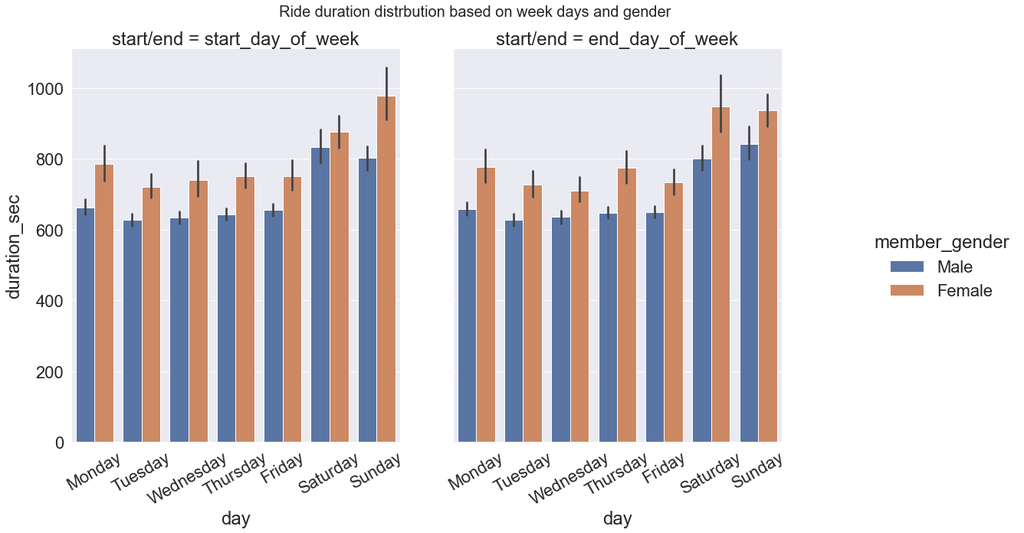

```python
## Plotting
g=sns.catplot(
    data=plot_data,
    x="day",
    y="duration_sec",
    hue="member_gender",
    col="start/end",
    order=day_order,
    kind="bar",
)
g.set_xticklabels(rotation=30)
g.fig.subplots_adjust(top=0.9) # adjust the Figure in rp
g.fig.suptitle('Ride duration distrbution based on week days and gender', fontsize=20)
g.fig.set_size_inches(20,10);
```

## What is the relation between user type and ride duration and days ?

> Does The day matter for having a ride ? the next graphs shows the relation between the day and the ride

```python
# selecting columns to plot
cols=['start_day_of_week', 'end_day_of_week', 'duration_sec', 'user_type']
# creating new data
plot_data = df[cols]
# Melting data
plot_data = plot_data.melt(id_vars=['duration_sec', 'user_type'], var_name='start/end', value_name='day')
plot_data.head(2)
```

|  | duration_sec | user_type | start/end | day |
| --- | --- | --- | --- | --- |
| 0 | 52185 | Customer | start_day_of_week | Thursday |
| 1 | 61854 | Customer | start_day_of_week | Thursday |

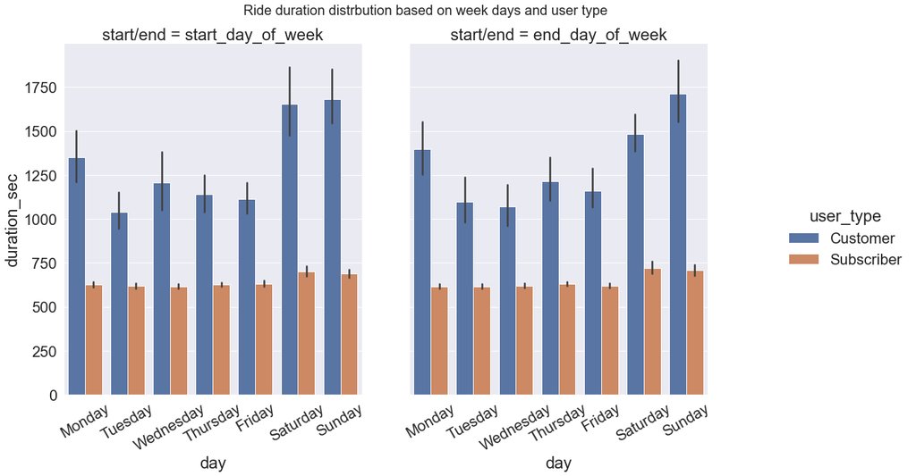

```python
## Plotting
g=sns.catplot(
    data=plot_data,
    x="day",
    y="duration_sec",
    hue="user_type",
    col="start/end",
    order=day_order,
    kind="bar",
);
g.set_xticklabels(rotation=30)
g.fig.subplots_adjust(top=0.9) # adjust the Figure in rp
g.fig.suptitle('Ride duration distrbution based on week days and user type', fontsize=20)
g.fig.set_size_inches(20,10);
```

## How time, gender and user type are related ?

The next graphs shows the relations between gender and user type and the ride time

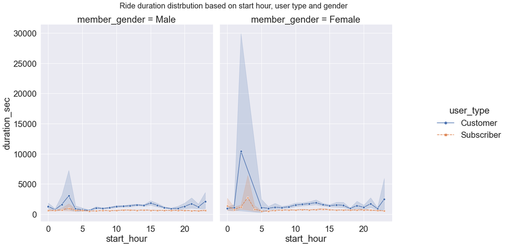

```python
# Start hour
g=sns.relplot(
    data=df, kind="line",
    x="start_hour", y="duration_sec", col="member_gender",
    hue="user_type", style="user_type", markers=True,
)
g.fig.subplots_adjust(top=0.9) # adjust the Figure in rp
g.fig.suptitle('Ride duration distrbution based on start hour, user type and gender', fontsize=20)
g.fig.set_size_inches(20,10);
```

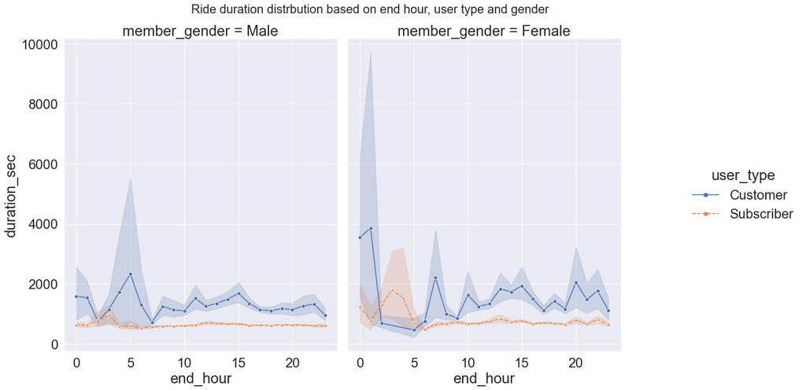

```python
# End hour
g=sns.relplot(
    data=df, kind="line",
    x="end_hour", y="duration_sec", col="member_gender",
    hue="user_type", style="user_type", markers=True,
)
g.fig.subplots_adjust(top=0.9) # adjust the Figure in rp
g.fig.suptitle('Ride duration distrbution based on end hour, user type and gender', fontsize=20)
g.fig.set_size_inches(20,10);
```

```python
!jupyter nbconvert FordBike_Part_II_Explanation.ipynb --to slides --post serve --no-input --no-prompt
```